# Climate Trend Analysis

Abigail Sanford, Julia Bickford, Andrea Cornelius

4/14/2023

### Reading in data

```r
library(lubridate)
library(tidyverse)
library(Kendall)
climtrend = read.table("thermal_precip_temp.csv",fill=TRUE,sep=',',header=T)
head(climtrend) # read in the data
```

```
##       STATION                                   NAME      DATE PRCP TMAX TMIN
## 1 USW00003104 DESERT RESORTS REGIONAL AIRPORT, CA US 5/12/1950    0   NA   NA
## 2 USW00003104 DESERT RESORTS REGIONAL AIRPORT, CA US 5/13/1950    0   94   67
## 3 USW00003104 DESERT RESORTS REGIONAL AIRPORT, CA US 5/14/1950    0   95   65
## 4 USW00003104 DESERT RESORTS REGIONAL AIRPORT, CA US 5/15/1950    0   98   64
## 5 USW00003104 DESERT RESORTS REGIONAL AIRPORT, CA US 5/16/1950    0   97   64
## 6 USW00003104 DESERT RESORTS REGIONAL AIRPORT, CA US 5/17/1950    0   88   63
```

```r
climtrendtidy <- climtrend %>%
  select(DATE, PRCP, TMAX, TMIN) %>% # selected the columns I want to keep which include date, precipitation, temperature max, and temperature minimum
  mutate(DATE = mdy(DATE)) %>% # converts the date column into the 'date' class
  mutate(YEAR = year(DATE)) %>% # Create new column with just the year in it
  mutate(MONTH = month(DATE))%>% # create new column with just the month in it
  drop_na()
```

### Running basic quality checks

Make a plot to see what data is missing.

Daily data of air temperature

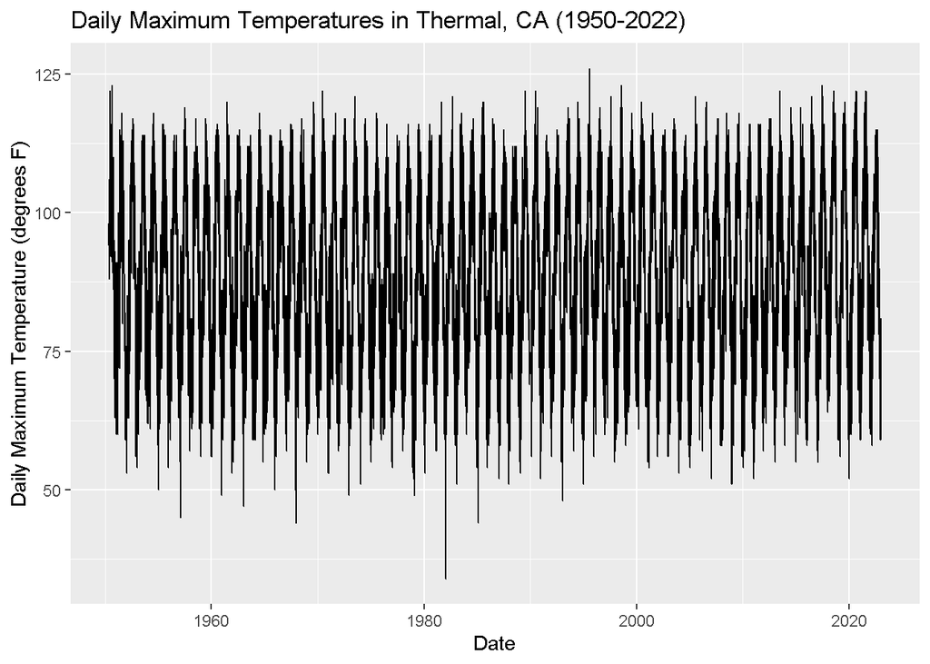

```r
ggplot(climtrendtidy, aes(DATE, TMAX)) +
  geom_line() +
  labs(y="Daily Maximum Temperature (degrees F)",
       x="Date",
       title = "Daily Maximum Temperatures in Thermal, CA (1950-2022)")
```

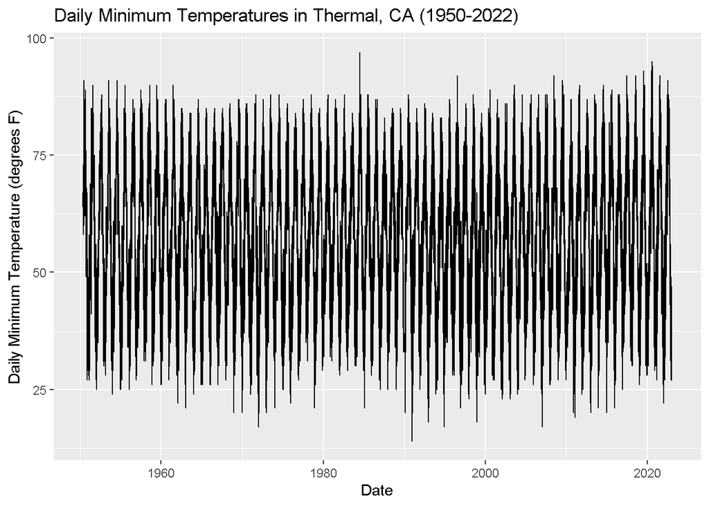

```r
ggplot(climtrendtidy, aes(DATE, TMIN)) +
  geom_line() +
  labs(y="Daily Minimum Temperature (degrees F)",
       x="Date",
       title = "Daily Minimum Temperatures in Thermal, CA (1950-2022)")
```

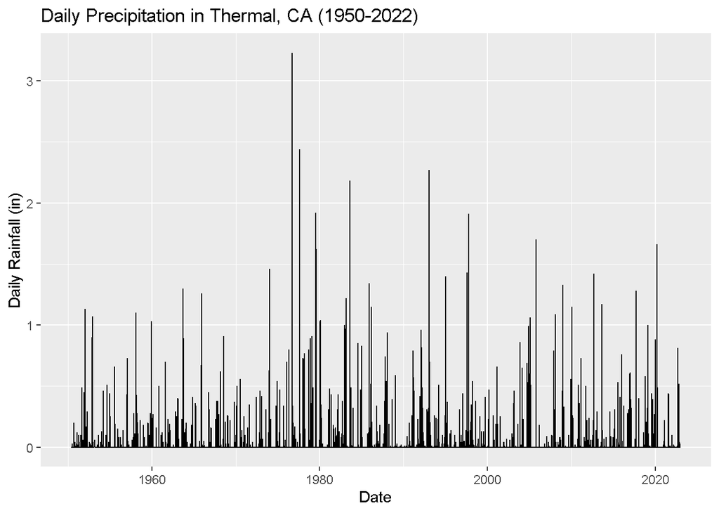

```r
ggplot(climtrendtidy, aes(DATE, PRCP)) +
  geom_line() +
  labs(y="Daily Rainfall (in)",
       x="Date",
       title = "Daily Precipitation in Thermal, CA (1950-2022)")
```

we need to check this: “Some values are”NA" in temperature and precipitation; these have been trimmed automatically by ggplot, but this may not be the case for all functions. In general, you’ll want to check meta data to see how missing data is labelled: -999 or NA are common choices." Ours is done as NA

### Determining whether there is a trend

```r
climyearmean <- climtrendtidy %>%
  group_by(YEAR) %>%
  summarize(tmax= mean(TMAX),
            tmin= mean(TMIN),
            precip= sum(PRCP))

climyearmean
```

```
## # A tibble: 73 x 4
##     YEAR  tmax  tmin precip
##    <dbl> <dbl> <dbl>  <dbl>
##  1  1950  96.5  62.5   0.31
##  2  1951  88.7  55.9   1.91
##  3  1952  88.2  57.3   5.47
##  4  1953  89.2  56.3   0.32
##  5  1954  89.8  57.1   1.76
##  6  1955  87.2  56.0   2.48
##  7  1956  89.2  56.2   0.49
##  8  1957  88.1  58.8   2.22
##  9  1958  90.0  58.9   2.94
## 10  1959  89.6  58.2   2.65
## # ... with 63 more rows
```

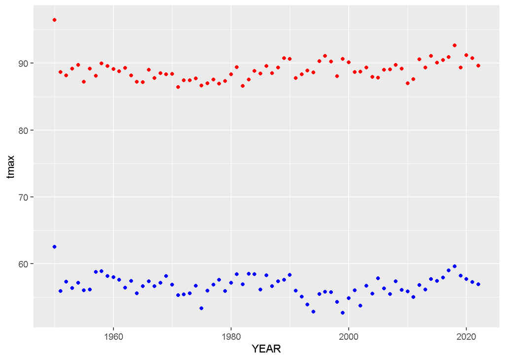

```r
ggplot(climyearmean, aes(x=YEAR, tmax)) +
  geom_point(col="red") +
  scale_y_continuous(limits=c(min(climyearmean$tmin),
                              max(climyearmean$tmax))) +
  geom_point(data=climyearmean, aes(x=YEAR, tmin), col="blue")
```

```r
a = ggplot(climyearmean, aes(x=YEAR, tmax)) +
  geom_point(col="red") +
  stat_smooth(method="lm", col="red") +
  scale_y_continuous(limits=c(min(climyearmean$tmin),
                              max(climyearmean$tmax))) +
  geom_point(data=climyearmean, aes(x=YEAR, tmin), col="blue")
```

Notice the different behavior of the min and max temperatures!

OK now let’s put a trend line on this thing.

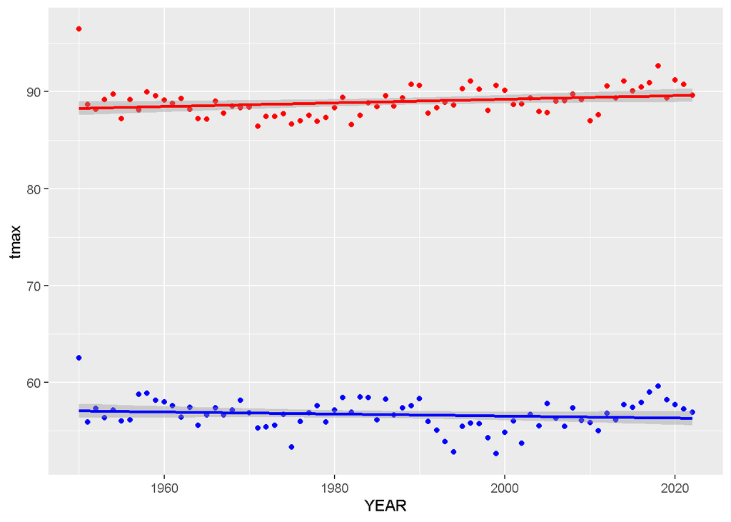

```r
# now lets add a trend line

a + geom_point(data=climyearmean, aes(x=YEAR, tmin), col="blue") +
  stat_smooth(data=climyearmean, aes(x=YEAR, tmin), col="blue", method="lm")
```

Now let’s calculate the slope (or how quickly temperatures are rising; we do this with linear regression)

```r
# minimum temperature regression line

slopetmin=lm(tmin~YEAR, data=climyearmean) # figure out slope of linear model

summary(slopetmin) # view linear model numbers
```

```
##
## Call:
## lm(formula = tmin ~ YEAR, data = climyearmean)
##
## Residuals:
##     Min      1Q  Median      3Q     Max
## -3.9224 -0.8530  0.0257  1.0196  5.4606
##
## Coefficients:
##             Estimate Std. Error t value Pr(>|t|)
## (Intercept) 77.50931   17.49778    4.43 3.35e-05 ***
## YEAR        -0.01048    0.00881   -1.19    0.238
## ---
## Signif. codes:  0 '***' 0.001 '**' 0.01 '*' 0.05 '.' 0.1 ' ' 1
##
## Residual standard error: 1.586 on 71 degrees of freedom
## Multiple R-squared:  0.01954,    Adjusted R-squared:  0.005735
## F-statistic: 1.415 on 1 and 71 DF,  p-value: 0.2381
```

```r
confint(slopetmin,"YEAR", level=0.95) #add confidence interval for model parameters
```

```
##            2.5 %      97.5 %
## YEAR -0.02804766 0.007085882
```

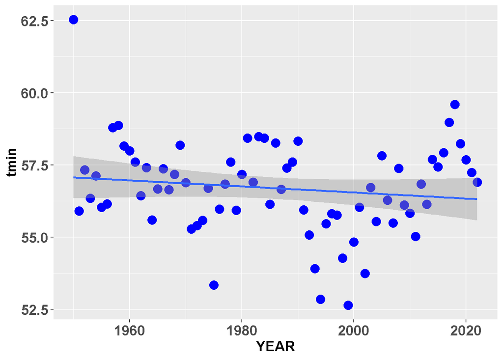

```r
ggplot(climyearmean, aes(x=YEAR, y=tmin)) +
  stat_summary(fun.y="mean", geom="point", col="blue", size=4) +
  theme(axis.text=element_text(size=14, face="bold"),
        axis.title=element_text(size=14, face="bold")) +
  geom_smooth(method="lm")
```

```r
# minimum temperature regression line

slopetmax=lm(tmax~YEAR, data=climyearmean) # figure out slope of linear model

summary(slopetmax) # view linear model numbers
```

```
##
## Call:
## lm(formula = tmax ~ YEAR, data = climyearmean)
##
## Residuals:
##     Min      1Q  Median      3Q     Max
## -2.4276 -1.1585 -0.2142  0.8080  8.1734
##
## Coefficients:
##              Estimate Std. Error t value Pr(>|t|)
## (Intercept) 51.552303  16.930139   3.045  0.00326 **
## YEAR         0.018842   0.008524   2.210  0.03030 *
## ---
## Signif. codes:  0 '***' 0.001 '**' 0.01 '*' 0.05 '.' 0.1 ' ' 1
##
## Residual standard error: 1.535 on 71 degrees of freedom
## Multiple R-squared:  0.06438,    Adjusted R-squared:  0.05121
## F-statistic: 4.886 on 1 and 71 DF,  p-value: 0.0303
```

```r
confint(slopetmax,"YEAR", level=0.95) #add confidence interval for model parameters
```

```
##            2.5 %     97.5 %
## YEAR 0.001845193 0.03583899
```

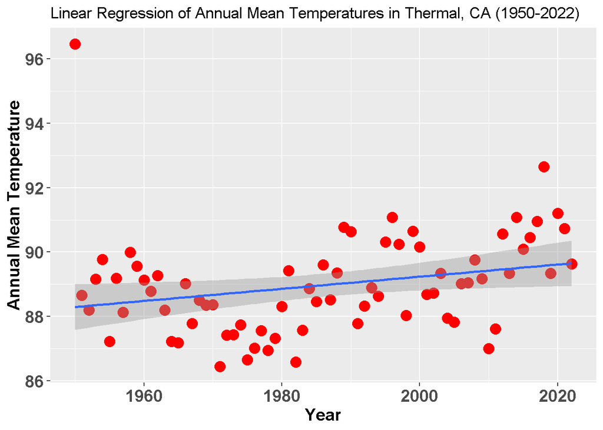

```r
ggplot(climyearmean, aes(x=YEAR, y=tmax)) +
  stat_summary(fun.y="mean", geom="point", col="red", size=4) +
  theme(axis.text=element_text(size=14, face="bold"),
        axis.title=element_text(size=14, face="bold")) +
  geom_smooth(method="lm") +
  labs(y = "Annual Mean Temperature",
       x = "Year",
       title = "Linear Regression of Annual Mean Temperatures in Thermal, CA (1950-2022)")
```

nullhypothesis: Year is not a predictor of annual mean temperature. We reject the null hypothesis due to a low p-value that is statistically significant.

### Aggregation: seasonal!

Are the hottest months getting hotter on average. need to look at average maximum hottest temp, in the months we are calling summer.

```r
# create a variable
climtrendtidy$season =
  ifelse((climtrendtidy$MONTH) %in% c(1,2,3,11,12), 1, 2)


climseasonmean <- climtrendtidy %>%
  group_by(YEAR, season) %>%
  summarize(tmax= mean(TMAX),
            tmin= mean(TMIN),
            precip= sum(PRCP)) %>%
  filter(season == "2")
climseasonmean
```

```
## # A tibble: 73 x 5
## # Groups:   YEAR [73]
##     YEAR season  tmax  tmin precip
##    <dbl>  <dbl> <dbl> <dbl>  <dbl>
##  1  1950      2 102.   69.0   0.26
##  2  1951      2  99    66.7   0.88
##  3  1952      2 101.   68.6   0.43
##  4  1953      2  97.6  66.0   0.16
##  5  1954      2  98.9  66.8   0.83
##  6  1955      2  97.2  66.0   0.89
##  7  1956      2  98.3  66.9   0.41
##  8  1957      2  97.7  68.5   0.79
##  9  1958      2 100.   69.3   0.74
## 10  1959      2  98.9  68.3   0.35
## # ... with 63 more rows
```

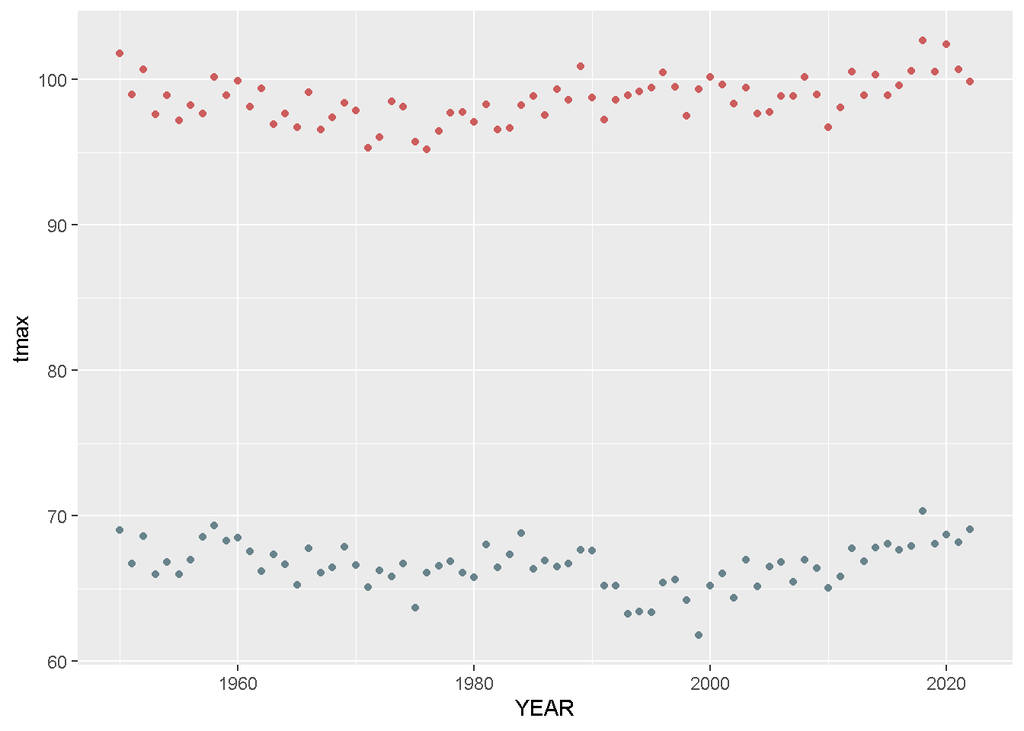

```r
ggplot(climseasonmean, aes(x=YEAR, tmax)) +
  geom_point(col="indianred") +
  scale_y_continuous(limits=c(min(climseasonmean$tmin),
                              max(climseasonmean$tmax))) +
  geom_point(data=climseasonmean, aes(x=YEAR, tmin), col="lightblue4")
```

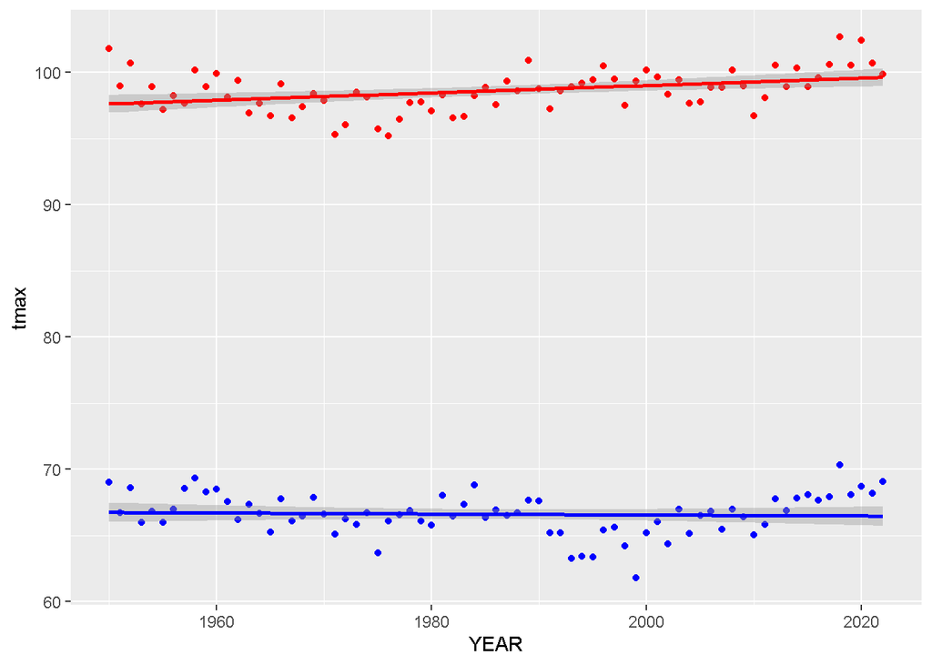

```r
b = ggplot(climseasonmean, aes(x=YEAR, tmax)) +
  geom_point(col="red") +
  stat_smooth(method="lm", col="red") +
  scale_y_continuous(limits=c(min(climseasonmean$tmin),
                              max(climseasonmean$tmax))) +
  geom_point(data=climseasonmean, aes(x=YEAR, tmin), col="blue")

b + geom_point(data=climseasonmean, aes(x=YEAR, tmin), col="blue") +
  stat_smooth(data=climseasonmean, aes(x=YEAR, tmin), col="blue", method="lm")
```

```r
# minimum temperature regression line

slopetminseason=lm(tmin~YEAR, data=climseasonmean) # figure out slope of linear model

summary(slopetminseason) # view linear model numbers
```

```
##
## Call:
## lm(formula = tmin ~ YEAR, data = climseasonmean)
##
## Residuals:
##     Min      1Q  Median      3Q     Max
## -4.7887 -0.8453 -0.0337  1.1769  3.8301
##
## Coefficients:
##              Estimate Std. Error t value Pr(>|t|)
## (Intercept) 74.135960  17.381190   4.265 6.06e-05 ***
## YEAR        -0.003795   0.008751  -0.434    0.666
## ---
## Signif. codes:  0 '***' 0.001 '**' 0.01 '*' 0.05 '.' 0.1 ' ' 1
##
## Residual standard error: 1.576 on 71 degrees of freedom
## Multiple R-squared:  0.002641,   Adjusted R-squared:  -0.01141
## F-statistic: 0.188 on 1 and 71 DF,  p-value: 0.6659
```

```r
confint(slopetminseason,"YEAR", level=0.95) #add confidence interval for model parameters
```

```
##           2.5 %     97.5 %
## YEAR -0.0212444 0.01365506
```

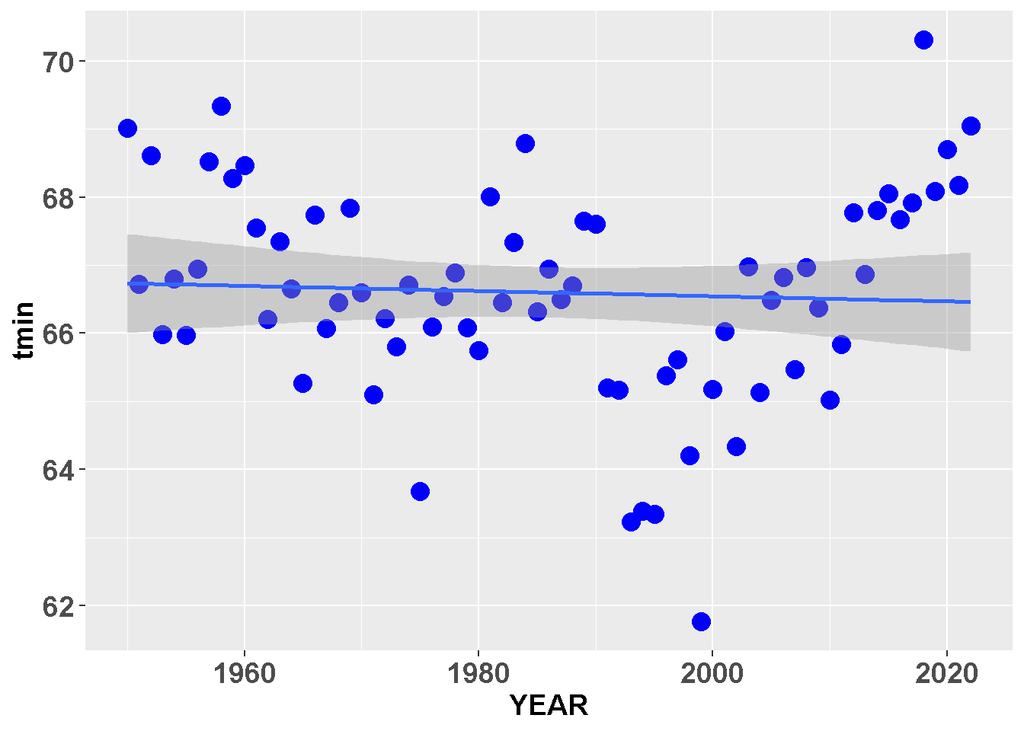

```r
ggplot(climseasonmean, aes(x=YEAR, y=tmin)) +
  stat_summary(fun.y="mean", geom="point", col="blue", size=4) +
  theme(axis.text=element_text(size=14, face="bold"),
        axis.title=element_text(size=14, face="bold")) +
  geom_smooth(method="lm")
```

```r
# minimum temperature regression line

slopetmaxseason=lm(tmax~YEAR, data=climseasonmean) # figure out slope of linear model

summary(slopetmaxseason) # view linear model numbers
```

```
##
## Call:
## lm(formula = tmax ~ YEAR, data = climseasonmean)
##
## Residuals:
##     Min      1Q  Median      3Q     Max
## -3.1637 -0.7322 -0.1030  0.9507  4.1672
##
## Coefficients:
##              Estimate Std. Error t value Pr(>|t|)
## (Intercept) 43.713486  15.971309   2.737 0.007829 **
## YEAR         0.027655   0.008041   3.439 0.000981 ***
## ---
## Signif. codes:  0 '***' 0.001 '**' 0.01 '*' 0.05 '.' 0.1 ' ' 1
##
## Residual standard error: 1.448 on 71 degrees of freedom
## Multiple R-squared:  0.1428, Adjusted R-squared:  0.1307
## F-statistic: 11.83 on 1 and 71 DF,  p-value: 0.0009808
```

```r
confint(slopetmaxseason,"YEAR", level=0.95) #add confidence interval for model parameters
```

```
##          2.5 %     97.5 %
## YEAR 0.0116208 0.04368937
```

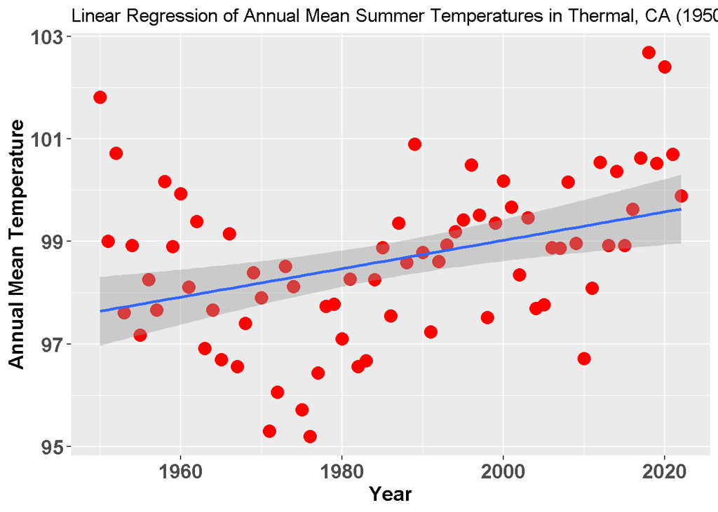

```r
ggplot(climseasonmean, aes(x=YEAR, y=tmax)) +
  stat_summary(fun.y="mean", geom="point", col="red", size=4) +
  theme(axis.text=element_text(size=14, face="bold"),
        axis.title=element_text(size=14, face="bold")) +
  geom_smooth(method="lm") +
  labs(y = "Annual Mean Temperature",
       x = "Year",
       title = "Linear Regression of Annual Mean Summer Temperatures in Thermal, CA (1950-2022)")
```